# Tarea 7

Juanes

2025-03-26

# HOLA!!

Bienvenidos a mi tarea de Modelos logisticos!!

Primero se cargan todas las librerias necesarias para los analisis y graficos.

```r
library(effects)
library(carData)
library(ggpubr)
library(MASS)
library(patchwork)
```

## Procesamiento de la Data

Cambiamos unicamente la columna de Suelo a columnas “dummy” para hacer el analisis.

```r
df<- BioModelo

clas_dummy<- model.matrix(~factor(df$suelo))

df<- data.frame(df, clas_dummy[,2:3])

print(head(df))
```

```
##   temperatura  humedad ph_suelo     suelo presencia_especie desarrollo_planta
## 1    17.19762 59.26444 6.678142 Arcilloso                 1        -1.3982410
## 2    18.84911 48.31349 6.170995    Limoso                 0         0.8010692
## 3    27.79354 53.65252 6.927601   Arenoso                 0         5.2857168
## 4    20.35254 59.71158 7.076468    Limoso                 0        -1.0745726
## 5    20.64644 66.70696 6.638137 Arcilloso                 0        -1.4943008
## 6    28.57532 43.49453 6.572052    Limoso                 1        10.2467211
##   factor.df.suelo.Arenoso factor.df.suelo.Limoso
## 1                       0                      0
## 2                       0                      1
## 3                       1                      0
## 4                       0                      1
## 5                       0                      0
## 6                       0                      1
```

## Modelo Logisitco MUltiple

Realizamos el modelo logisitco multiple con la funcion `glm()` y imprimimos los resultados.

```r
modelo_log<- glm(presencia_especie~ temperatura+humedad+ph_suelo+desarrollo_planta+
                   factor.df.suelo.Arenoso+factor.df.suelo.Limoso,
                 family = "binomial", data= df)

summary(modelo_log)
```

```
##
## Call:
## glm(formula = presencia_especie ~ temperatura + humedad + ph_suelo +
##     desarrollo_planta + factor.df.suelo.Arenoso + factor.df.suelo.Limoso,
##     family = "binomial", data = df)
##
## Coefficients:
##                         Estimate Std. Error z value Pr(>|z|)
## (Intercept)             -1.76799    1.52841  -1.157    0.247
## temperatura             -0.02844    0.03117  -0.912    0.362
## humedad                  0.02494    0.01784   1.398    0.162
## ph_suelo                 0.11674    0.19911   0.586    0.558
## desarrollo_planta        0.06067    0.04915   1.234    0.217
## factor.df.suelo.Arenoso  0.21557    0.25086   0.859    0.390
## factor.df.suelo.Limoso  -0.08054    0.26126  -0.308    0.758
##
## (Dispersion parameter for binomial family taken to be 1)
##
##     Null deviance: 554.27  on 399  degrees of freedom
## Residual deviance: 550.99  on 393  degrees of freedom
## AIC: 564.99
##
## Number of Fisher Scoring iterations: 4
```

Encontramos que, OH SORPRESA, el modelo es pésimo y ninguna variable se ajusta es un predictor significativo de la presencia o ausencia de la especie.

Podemos visualizar el modelo en la siguiente grafica:

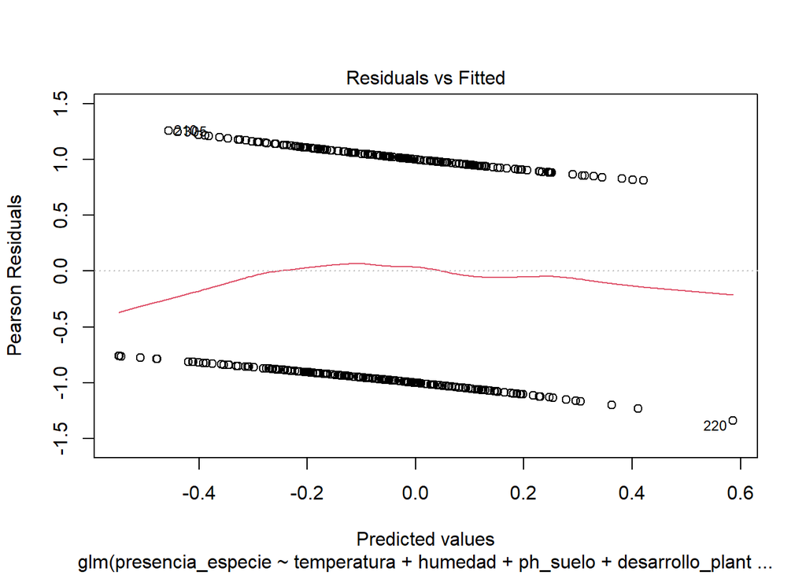

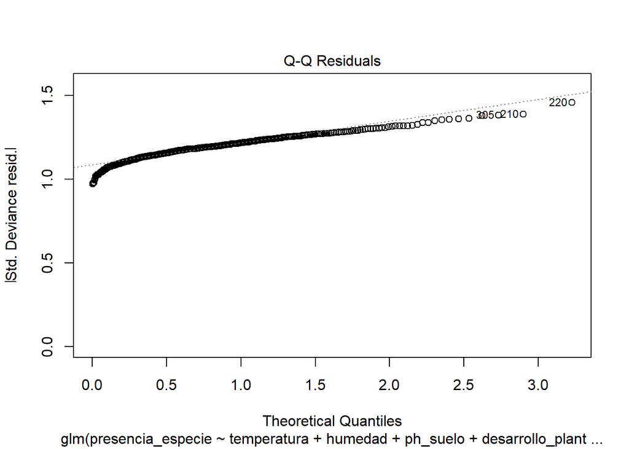

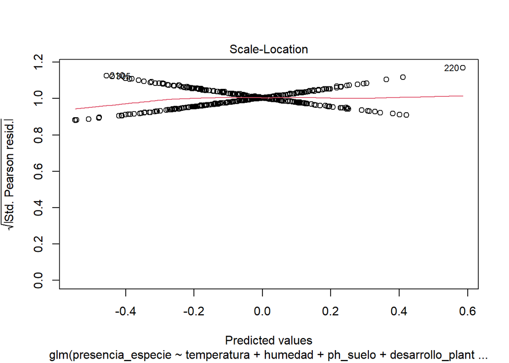

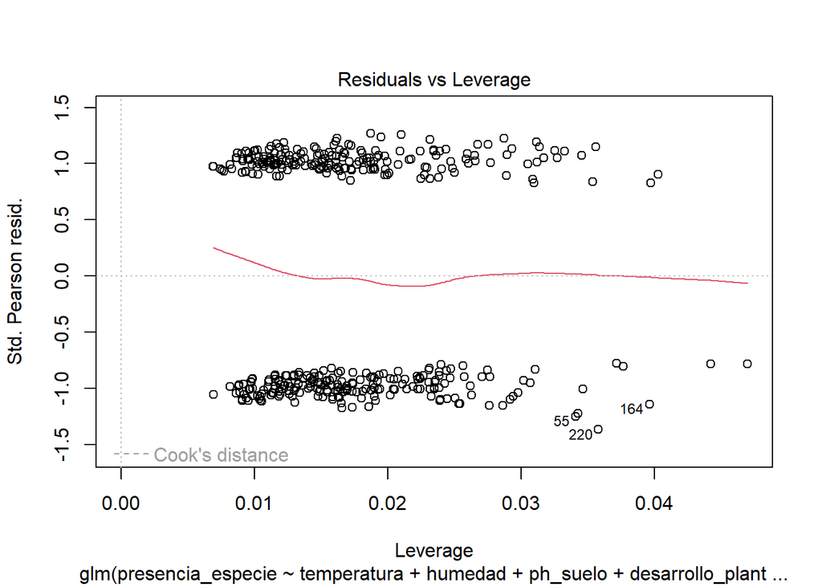

```r
plot(modelo_log)
```

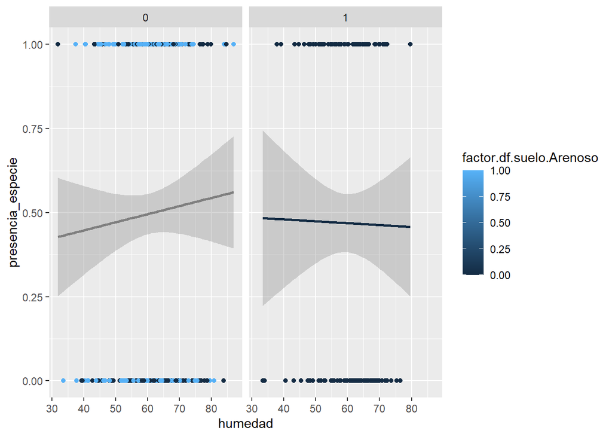

```r
p1<- ggplot(data= df, aes(x= humedad, y= presencia_especie, color = factor.df.suelo.Arenoso ))+
  facet_grid(~factor.df.suelo.Limoso)+
  geom_smooth(method = "glm")+
  geom_point()
p1
```

## Evaluación del Modelo

Primero se transforman los ceficientes a probabilidades para poder leerlos…

```r
exp(coef(modelo_log))
```

```
##             (Intercept)             temperatura                 humedad
##               0.1706753               0.9719581               1.0252571
##                ph_suelo       desarrollo_planta factor.df.suelo.Arenoso
##               1.1238320               1.0625490               1.2405658
##  factor.df.suelo.Limoso
##               0.9226143
```

```r
odds<- exp(coef(modelo_log))/(1+exp(coef(modelo_log)))
```

Recordemos que ninguno de los valores de los coefiscientes son fiables puesto que no son significativos.

### Evaluadores basados en Matriz de Confusión

Para poder evaluar el modelo calculamos primero la matriz de confusión con el fin de poder evaluar cuantitativamente la presición del modelo. Para esto primero calculamos las predicciones del modelo en una nueva columna (
$$\alpha = 0.5$$
)

```r
df$Predicciones <- predict(modelo_log, type = "response")

df$Clasificacion<- ifelse(df$Predicciones > 0.5, 1, 0)
print(head(df))
```

```
##   temperatura  humedad ph_suelo     suelo presencia_especie desarrollo_planta
## 1    17.19762 59.26444 6.678142 Arcilloso                 1        -1.3982410
## 2    18.84911 48.31349 6.170995    Limoso                 0         0.8010692
## 3    27.79354 53.65252 6.927601   Arenoso                 0         5.2857168
## 4    20.35254 59.71158 7.076468    Limoso                 0        -1.0745726
## 5    20.64644 66.70696 6.638137 Arcilloso                 0        -1.4943008
## 6    28.57532 43.49453 6.572052    Limoso                 1        10.2467211
##   factor.df.suelo.Arenoso factor.df.suelo.Limoso Predicciones Clasificacion
## 1                       0                      0    0.4789925             0
## 2                       0                      1    0.3987869             0
## 3                       1                      0    0.5311537             1
## 4                       0                      1    0.4558491             0
## 5                       0                      0    0.4982426             0
## 6                       0                      1    0.4532704             0
```

```r
tablaconf<- table(Real= df$presencia_especie, Predecido= df$Clasificacion)
tablaconf
```

```
##     Predecido
## Real   0   1
##    0 130  75
##    1 114  81
```

Ahora si podemos calcular la precision, sensibilidad y especificidad del modelo

```r
precision <- sum(diag(tablaconf)) / sum(tablaconf)
sensibilidad <- tablaconf[2, 2] / sum(tablaconf[2, ])
especificidad <- tablaconf[1, 1] / sum(tablaconf[1, ])

print("Presicion")
```

```
## [1] "Presicion"
```

```r
print(precision)
```

```
## [1] 0.5275
```

```r
print("Sensibilidad")
```

```
## [1] "Sensibilidad"
```

```r
print(sensibilidad)
```

```
## [1] 0.4153846
```

```r
print("Especificidad")
```

```
## [1] "Especificidad"
```

```r
print(especificidad)
```

```
## [1] 0.6341463
```

De estos valores podemos decir que el modelo predice correctamente la presencia o ausencia de la especie apenas ligeramente mejor que el asar “Presicion = 0.5275”. La Sensibilidad y Especificidad refieren la razon entre verdaderos positivos y verdaderos negativos (verdaderamente presente o ausente) vs. los falsos positivos y negativos del modelo. y en general podemos observar como el modelo no es muy util para predecir ninguno.